# Polinomi u pythonu

```python
import platform
```

```python
platform.platform()
```

```
'Linux-5.4.143-1-MANJARO-x86_64-with-glibc2.33'
```

```python
platform.python_version()
```

```
'3.9.6'
```

#### Polinomi u numpy modulu

```python
import numpy as np
```

```python
np.__version__
```

```
'1.20.3'
```

```python
from pylab import *
```

S polinomima jedne varijable unutar numpy modula najjednostavnije je raditi preko poly1d klase koja olakšava rad s polinomima što se tiče pisanja koda.

$f(x)=x^5-3x^3-5x,\quad g(x)=x^2-x+1$

```python
f=np.poly1d([1,0,-3,0,-5,0])
g=np.poly1d([1,-1,1])
```

```python
print(f)
```

```
   5     3
1 x - 3 x - 5 x
```

```python
print(g)
```

```
   2
1 x - 1 x + 1
```

Ako želimo neku drugu varijablu kod ispisa, onda to navedemo kod definiranja polinoma.

```python
g1=np.poly1d([1,-1,1],variable='u')
```

```python
print(g1)
```

```
   2
1 u - 1 u + 1
```

#### Koeficijenti polinoma

```python
f.c
```

```
array([ 1,  0, -3,  0, -5,  0])
```

```python
g.c
```

```
array([ 1, -1,  1])
```

f[k] je koeficijent uz potenciju $x^k$

```python
f[3]
```

```
-3
```

```python
f[2]
```

```
0
```

```python
g[0]
```

```
1
```

#### Stupanj polinoma

```python
f.o
```

```
5
```

```python
g.o
```

```
2
```

#### Računanje vrijednosti polinoma u točki

```python
f(3)
```

```
147
```

```python
g(3)
```

```
7
```

```python
g(3.21)
```

```
8.094100000000001
```

#### Derivacija polinoma

```python
f.deriv()
```

```
poly1d([ 5,  0, -9,  0, -5])
```

```python
print(f.deriv())
```

```
   4     2
5 x - 9 x - 5
```

```python
g.deriv()
```

```
poly1d([ 2, -1])
```

```python
print(g.deriv())
```

```
2 x - 1
```

#### Derivacije višeg reda

```python
f.deriv(2)
```

```
poly1d([ 20,   0, -18,   0])
```

```python
print(f.deriv(2))
```

```
    3
20 x - 18 x
```

```python
f.deriv(3)
```

```
poly1d([ 60,   0, -18])
```

```python
print(f.deriv(3))
```

```
    2
60 x - 18
```

#### Integral polinoma

```python
f.integ()
```

```
poly1d([ 0.16666667,  0.        , -0.75      ,  0.        , -2.5       ,
        0.        ,  0.        ])
```

```python
print(f.integ())
```

```
        6        4       2
0.1667 x - 0.75 x - 2.5 x
```

```python
g.integ()
```

```
poly1d([ 0.33333333, -0.5       ,  1.        ,  0.        ])
```

```python
print(g.integ())
```

```
        3       2
0.3333 x - 0.5 x + 1 x
```

#### Zbrajanje polinoma

```python
f+g
```

```
poly1d([ 1,  0, -3,  1, -6,  1])
```

```python
print(f+g)
```

```
   5     3     2
1 x - 3 x + 1 x - 6 x + 1
```

```python
(f+g)(3)
```

```
154
```

#### Oduzimanje polinoma

```python
f-g
```

```
poly1d([ 1,  0, -3, -1, -4, -1])
```

```python
print(f-g)
```

```
   5     3     2
1 x - 3 x - 1 x - 4 x - 1
```

#### Množenje polinoma

```python
f*g
```

```
poly1d([ 1, -1, -2,  3, -8,  5, -5,  0])
```

```python
print(f*g)
```

```
   7     6     5     4     3     2
1 x - 1 x - 2 x + 3 x - 8 x + 5 x - 5 x
```

#### Potenciranje polinoma

```python
f**3
```

```
poly1d([   1,    0,   -9,    0,   12,    0,   63,    0,  -60,    0, -225,
          0, -125,    0,    0,    0])
```

```python
print(f**3)
```

```
   15     13      11      9      7       5       3
1 x  - 9 x  + 12 x  + 63 x - 60 x - 225 x - 125 x
```

#### Polinom $f^3g+2f$

```python
H=f**3*g+2*f
H
```

```
poly1d([   1,   -1,   -8,    9,    3,  -12,   75,  -63,    3,   60, -285,
        225, -348,  125, -131,    0,  -10,    0])
```

```python
print(H)
```

```
   17     16     15     14     13      12      11      10     9      8
1 x  - 1 x  - 8 x  + 9 x  + 3 x  - 12 x  + 75 x  - 63 x  + 3 x + 60 x
        7       6       5       4       3
 - 285 x + 225 x - 348 x + 125 x - 131 x - 10 x
```

suma koeficijenata polinoma $f^3g+2f$

```python
H(1)
```

```
-357
```

#### Dijeljenje polinoma

```python
kvocijent, ostatak = f/g
```

```python
kvocijent
```

```
poly1d([ 1.,  1., -3., -4.])
```

```python
print(kvocijent)
```

```
   3     2
1 x + 1 x - 3 x - 4
```

```python
ostatak
```

```
poly1d([-6.,  4.])
```

```python
print(ostatak)
```

```
-6 x + 4
```

```python
f/g
```

```
(poly1d([ 1.,  1., -3., -4.]), poly1d([-6.,  4.]))
```

#### Nultočke polinoma

```python
f.r
```

```
array([-2.04757965e+00+0.j        ,  2.04757965e+00+0.j        ,
       -1.38777878e-17+1.09205421j, -1.38777878e-17-1.09205421j,
        0.00000000e+00+0.j        ])
```

```python
g.r
```

```
array([0.5+0.8660254j, 0.5-0.8660254j])
```

#### Dobivanje samo realnih nultočaka

```python
nul_real = np.extract(f.r.imag == 0, f.r)
nul_real
```

```
array([-2.04757965+0.j,  2.04757965+0.j,  0.        +0.j])
```

Ljepši zapis bez člana 0.j

```python
only_real = lambda x: x.real
vector_real = np.vectorize(only_real)
```

```python
vector_real(nul_real)
```

```
array([-2.04757965,  2.04757965,  0.        ])
```

### 1. zadatak

Zadane su točke $(-2,0),(-1,1),(1,2),(2,3.89)$. Odredite polinom najmanjeg stupnja čiji graf prolazi kroz zadane točke.

### Rješenje

```python
import scipy.interpolate as scip
```

```python
xkor=[-2,-1,1,2]
ykor=[0,1,2,3.89]
```

```python
pol=scip.lagrange(xkor,ykor)
pol
```

```
poly1d([0.1575    , 0.14833333, 0.3425    , 1.35166667])
```

Pazite, u print ispisu neki koeficijenti mogu biti ispisani s manjom preciznošću.

```python
print(pol)
```

```
        3          2
0.1575 x + 0.1483 x + 0.3425 x + 1.352
```

```python
pol.c
```

```
array([0.1575    , 0.14833333, 0.3425    , 1.35166667])
```

#### slika

```python
xp=np.arange(-2.5,2.5,0.01)
yp=pol(xp)
```

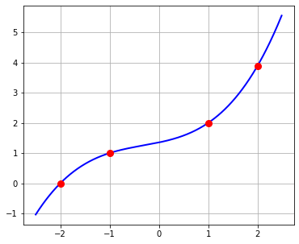

```python
figure(figsize=(6,5))
grid(True)
plot(xp,yp,'b-',xkor,ykor,'ro',markersize=8,linewidth=2);
```

### 2. zadatak

Odredite sve nultočke polinoma $p(x)=-2x^7+3x^6+4x^5-5x^4+x^3+2x^2+8x+12.$

### Rješenje

```python
p=np.poly1d([-2,3,4,-5,1,2,8,12])
```

#### sve nultočke u polju $\mathbb{C}$

```python
p.r
```

```
array([ 2.13930159+0.j        ,  1.0936878 +0.92373329j,
        1.0936878 -0.92373329j, -0.24213151+0.97254029j,
       -0.24213151-0.97254029j, -1.26767181+0.j        ,
       -1.07474237+0.j        ])
```

#### samo realne nultočke

```python
nul_real=np.extract(p.r.imag==0, p.r)
nul_real
```

```
array([ 2.13930159+0.j, -1.26767181+0.j, -1.07474237+0.j])
```

ljepši zapis bez člana 0.j

```python
only_real = lambda x: x.real
vector_real = np.vectorize(only_real)
```

```python
nul_real=vector_real(nul_real)
nul_real
```

```
array([ 2.13930159, -1.26767181, -1.07474237])
```

najveća realna nultočka

```python
max(nul_real)
```

```
2.1393015909951143
```

najmanja realna nultočka

```python
min(nul_real)
```

```
-1.267671807727639
```

#### slika

```python
x1=np.arange(-1.5,2.2,0.04)
y1=p(x1)
```

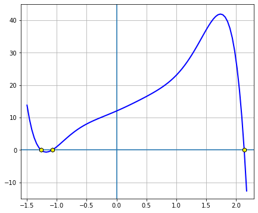

```python
figure(figsize=(7,6))
grid(True)
xlim(-1.6,2.3)
ylim(-15,45)
hlines(0,-1.6,2.3)
vlines(0,-15,45)
plot(x1,y1,'b-',linewidth=2)
plot(nul_real,[0,0,0],c='yellow',marker='h',ls='',ms=7,markeredgecolor='k');
```

### 3. zadatak

Razvijte polinom $p(x)=-2x^7+3x^6+4x^5-5x^4+x^3+2x^2+8x+12$ po potencijama od $x+5.$

### Rješenje

```python
import math
```

```python
p=np.poly1d([-2,3,4,-5,1,2,8,12])
```

S obzirom da imamo dostupnu naredbu za traženje derivacija polinoma, možemo brzo dobiti koeficijente u razvoju koristeći formulu $c_k=\frac{p(k)(a)}{k!}$ pri čemu je $c_k$ koeficijent uz potenciju $(x-a)^k$.

```python
razvoj=[p.deriv(k)(-5)/math.factorial(k) for k in range(p.o+1)]
razvoj
```

```
[187397.0, -259937.0, 153612.0, -50149.0, 9770.0, -1136.0, 73.0, -2.0]
```

Element s indeksom $k$ u dobivenoj listi daje koeficijent $c_k$.

##### koeficijent uz potenciju $(x+5)^3$

```python
razvoj[3]
```

```
-50149.0
```

##### koeficijent uz potenciju $(x+5)^0$, tj. slobodni član

```python
razvoj[0]
```

```
187397.0
```

Također možemo koristiti i Hornerov algoritam

```python
kv=p
lin=np.poly1d([1,5])
raz=[]
for k in range(p.o+1):
    kv,ost=kv/lin
    raz.append(ost[0])
```

```python
raz
```

```
[187397.0, -259937.0, 153612.0, -50149.0, 9770.0, -1136.0, 73.0, -2.0]
```

#### Možemo implementirati vlastite funkcije za brže rješavanje zadataka

Funkcije se nalaze u datoteci MMZI.py

Hornerov algoritam je brži od algoritma preko derivacija.

```python
import sys
sys.path.append("..")
import MMZI
```

```python
%time
MMZI.razvoj_der(p,-5)
```

```
CPU times: user 4 µs, sys: 0 ns, total: 4 µs
Wall time: 8.11 µs
```

```
[187397.0, -259937.0, 153612.0, -50149.0, 9770.0, -1136.0, 73.0, -2.0]
```

```python
%time
MMZI.razvoj_horner(p,-5)
```

```
CPU times: user 3 µs, sys: 0 ns, total: 3 µs
Wall time: 6.68 µs
```

```
[187397.0, -259937.0, 153612.0, -50149.0, 9770.0, -1136.0, 73.0, -2.0]
```

### 4. zadatak

Odredite Ferrarijevu rezolventu algebarske jednadžbe 4. reda $-5x^4+2x^3-7x^2+4x-2=0.$

### Rješenje

Implementirana funkcija se nalazi u datoteci MMZI.py

```python
rez=MMZI.Ferrari_rezolventa([-5,2,-7,4,-2])
rez
```

```
poly1d([-8.   ,  5.6  ,  2.56 , -1.536])
```

```python
print(rez)
```

```
    3       2
-8 x + 5.6 x + 2.56 x - 1.536
```

U ovom slučaju rezolventa ima sva rješenja realna.

```python
rez.r
```

```
array([-0.54244289,  0.8       ,  0.44244289])
```

#### slika

```python
x2=np.arange(-1,1.1,0.02)
y2=rez(x2)
```

```python
q=np.poly1d([-5,2,-7,4,-2])
x3=np.arange(-1,1.5,0.02)
y3=q(x3)
```

Promatrani polinom 4. stupnja nema niti jednu realnu nultočku.

```python
q.r
```

```
array([-0.14494897+1.12644917j, -0.14494897-1.12644917j,
        0.34494897+0.43716388j,  0.34494897-0.43716388j])
```

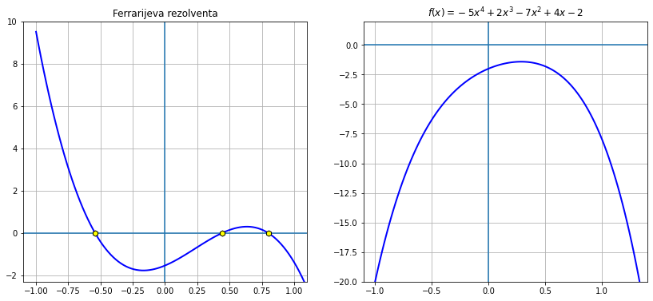

```python
figure(figsize=(14,6))
subplot(1,2,1)
title('Ferrarijeva rezolventa')
grid(True)
xlim(-1.1,1.1)
ylim(-2.3,10)
hlines(0,-1.1,1.1)
vlines(0,-2.3,10)
plot(x2,y2,'b-',linewidth=2)
plot(rez.r,[0,0,0],c='yellow',marker='h',ls='',ms=7,markeredgecolor='k')
subplot(1,2,2)
title('$f(x)=-5x^4+2x^3-7x^2+4x-2$')
grid(True)
xlim(-1.1,1.4)
ylim(-20,2)
hlines(0,-1.1,1.4)
vlines(0,-20,2)
plot(x3,y3,'b-',linewidth=2);
```

#### Polinomi u sympy modulu

```python
import sympy as sp
```

```python
sp.__version__
```

```
'1.8'
```

```python
sp.init_printing()
```

```python
import matplotlib.pyplot as plt
```

Unutar sympy modula možemo raditi s polinomima kao simboličkim izrazima ili preko klase Poly prilagođene za rad s polinomima. Ovdje navodimo samo nekoliko osnovnih stvari koristeći klasu Poly.

```python
x=sp.Symbol('x')
```

```python
f=sp.Poly(x**5-3*x**3-5*x)
g=sp.Poly(x**2-x+1)
```

```python
f
```

$\displaystyle \operatorname{Poly}{\left( x^{5} - 3 x^{3} - 5 x, x, domain=\mathbb{Z} \right)}$

```python
g
```

$\displaystyle \operatorname{Poly}{\left( x^{2} - x + 1, x, domain=\mathbb{Z} \right)}$

```python
f.as_expr()
```

$\displaystyle x^{5} - 3 x^{3} - 5 x$

```python
g.as_expr()
```

$\displaystyle x^{2} - x + 1$

#### Koeficijenti polinoma

```python
f.all_coeffs()
```

$\displaystyle \left[ 1, \ 0, \ -3, \ 0, \ -5, \ 0\right]$

```python
g.all_coeffs()
```

$\displaystyle \left[ 1, \ -1, \ 1\right]$

na poziciji s indeksom $-(k+1)$ je koeficijent uz potenciju $x^k$

```python
f.all_coeffs()[-4]
```

$\displaystyle -3$

```python
f.all_coeffs()[-3]
```

$\displaystyle 0$

```python
g.all_coeffs()[-1]
```

$\displaystyle 1$

#### Stupanj polinoma

```python
f.degree()
```

$\displaystyle 5$

```python
g.degree()
```

$\displaystyle 2$

#### Računanje vrijednosti polinoma u točki

```python
f(3)
```

$\displaystyle 147$

```python
g(3)
```

$\displaystyle 7$

```python
g(3.21)
```

$\displaystyle 8.0941$

#### Derivacija polinoma

```python
f.diff(x)
```

$\displaystyle \operatorname{Poly}{\left( 5 x^{4} - 9 x^{2} - 5, x, domain=\mathbb{Z} \right)}$

```python
f.diff(x).as_expr()
```

$\displaystyle 5 x^{4} - 9 x^{2} - 5$

```python
g.diff(x)
```

$\displaystyle \operatorname{Poly}{\left( 2 x - 1, x, domain=\mathbb{Z} \right)}$

```python
g.diff(x).as_expr()
```

$\displaystyle 2 x - 1$

#### Derivacije višeg reda

```python
f.diff((x,2))
```

$\displaystyle \operatorname{Poly}{\left( 20 x^{3} - 18 x, x, domain=\mathbb{Z} \right)}$

```python
f.diff((x,2)).as_expr()
```

$\displaystyle 20 x^{3} - 18 x$

```python
f.diff((x,3))
```

$\displaystyle \operatorname{Poly}{\left( 60 x^{2} - 18, x, domain=\mathbb{Z} \right)}$

```python
f.diff((x,3)).as_expr()
```

$\displaystyle 60 x^{2} - 18$

#### Integral polinoma

```python
f.integrate(x)
```

$\displaystyle \operatorname{Poly}{\left( \frac{1}{6} x^{6} - \frac{3}{4} x^{4} - \frac{5}{2} x^{2}, x, domain=\mathbb{Q} \right)}$

```python
f.integrate(x).as_expr()
```

$\displaystyle \frac{x^{6}}{6} - \frac{3 x^{4}}{4} - \frac{5 x^{2}}{2}$

```python
g.integrate(x)
```

$\displaystyle \operatorname{Poly}{\left( \frac{1}{3} x^{3} - \frac{1}{2} x^{2} + x, x, domain=\mathbb{Q} \right)}$

```python
g.integrate(x).as_expr()
```

$\displaystyle \frac{x^{3}}{3} - \frac{x^{2}}{2} + x$

#### Zbrajanje polinoma

```python
f+g
```

$\displaystyle \operatorname{Poly}{\left( x^{5} - 3 x^{3} + x^{2} - 6 x + 1, x, domain=\mathbb{Z} \right)}$

```python
(f+g).as_expr()
```

$\displaystyle x^{5} - 3 x^{3} + x^{2} - 6 x + 1$

```python
(f+g)(3)
```

$\displaystyle 154$

#### Oduzimanje polinoma

```python
f-g
```

$\displaystyle \operatorname{Poly}{\left( x^{5} - 3 x^{3} - x^{2} - 4 x - 1, x, domain=\mathbb{Z} \right)}$

```python
(f-g).as_expr()
```

$\displaystyle x^{5} - 3 x^{3} - x^{2} - 4 x - 1$

#### Množenje polinoma

```python
f*g
```

$\displaystyle \operatorname{Poly}{\left( x^{7} - x^{6} - 2 x^{5} + 3 x^{4} - 8 x^{3} + 5 x^{2} - 5 x, x, domain=\mathbb{Z} \right)}$

```python
(f*g).as_expr()
```

$\displaystyle x^{7} - x^{6} - 2 x^{5} + 3 x^{4} - 8 x^{3} + 5 x^{2} - 5 x$

#### Potenciranje polinoma

```python
f**3
```

$\displaystyle \operatorname{Poly}{\left( x^{15} - 9 x^{13} + 12 x^{11} + 63 x^{9} - 60 x^{7} - 225 x^{5} - 125 x^{3}, x, domain=\mathbb{Z} \right)}$

```python
(f**3).as_expr()
```

$\displaystyle x^{15} - 9 x^{13} + 12 x^{11} + 63 x^{9} - 60 x^{7} - 225 x^{5} - 125 x^{3}$

#### Polinom $f^3g+2f$

```python
H=f**3*g+2*f
H
```

$\displaystyle \operatorname{Poly}{\left( x^{17} - x^{16} - 8 x^{15} + 9 x^{14} + 3 x^{13} - 12 x^{12} + 75 x^{11} - 63 x^{10} + 3 x^{9} + 60 x^{8} - 285 x^{7} + 225 x^{6} - 348 x^{5} + 125 x^{4} - 131 x^{3} - 10 x, x, domain=\mathbb{Z} \right)}$

```python
H.as_expr()
```

$\displaystyle x^{17} - x^{16} - 8 x^{15} + 9 x^{14} + 3 x^{13} - 12 x^{12} + 75 x^{11} - 63 x^{10} + 3 x^{9} + 60 x^{8} - 285 x^{7} + 225 x^{6} - 348 x^{5} + 125 x^{4} - 131 x^{3} - 10 x$

suma koeficijenata polinoma $f^3g+2f$

```python
H(1)
```

$\displaystyle -357$

#### Dijeljenje polinoma

```python
sp.div(f,g)
```

$\displaystyle \left( \operatorname{Poly}{\left( x^{3} + x^{2} - 3 x - 4, x, domain=\mathbb{Z} \right)}, \ \operatorname{Poly}{\left( -6 x + 4, x, domain=\mathbb{Z} \right)}\right)$

```python
kvocijent,ostatak=sp.div(f,g)
```

```python
kvocijent.as_expr()
```

$\displaystyle x^{3} + x^{2} - 3 x - 4$

```python
ostatak.as_expr()
```

$\displaystyle 4 - 6 x$

S obzirom da za polinome s koeficijentima iz nekog prstena ne vrijedi općenito teorem o dijeljenju, sympy po potrebi polinome s cjelobrojnim koeficijentima gleda kao na polinome s racionalnim koeficijentima prilikom dijeljenja.

```python
h=sp.Poly(3*x**2-x+5)
h.as_expr()
```

$\displaystyle 3 x^{2} - x + 5$

```python
sp.div(f,h)
```

$\displaystyle \left( \operatorname{Poly}{\left( \frac{1}{3} x^{3} + \frac{1}{9} x^{2} - \frac{41}{27} x - \frac{56}{81}, x, domain=\mathbb{Q} \right)}, \ \operatorname{Poly}{\left( \frac{154}{81} x + \frac{280}{81}, x, domain=\mathbb{Q} \right)}\right)$

Možemo prisiliti sympy da dijeljenje obavi nad prstenom cijelih brojeva, međutim vidimo da onda ne vrijedi teorem o dijeljenju polinoma, tj. stupanj ostatka nije strogo manji od stupnja polinoma s kojim se dijelilo.

```python
sp.div(f,h,domain='ZZ')
```

$\displaystyle \left( \operatorname{Poly}{\left( 0, x, domain=\mathbb{Z} \right)}, \ \operatorname{Poly}{\left( x^{5} - 3 x^{3} - 5 x, x, domain=\mathbb{Z} \right)}\right)$

#### Nultočke polinoma

Egzaktno općenito nije moguće uvijek pronaći sve nultočke.

```python
f.all_roots()
```

$\displaystyle \left[ \operatorname{CRootOf} {\left(x^{4} - 3 x^{2} - 5, 0\right)}, \ 0, \ \operatorname{CRootOf} {\left(x^{4} - 3 x^{2} - 5, 1\right)}, \ \operatorname{CRootOf} {\left(x^{4} - 3 x^{2} - 5, 2\right)}, \ \operatorname{CRootOf} {\left(x^{4} - 3 x^{2} - 5, 3\right)}\right]$

Numeričkim putem možemo pronaći sve nultočke polinoma.

```python
f.nroots()
```

$\displaystyle \left[ -2.04757964523172, \ 0.0, \ 2.04757964523172, \ - 1.09205421274186 i, \ 1.09205421274186 i\right]$

Samo realne nultočke

```python
list(filter(lambda x: sp.im(x)==0, f.nroots()))
```

$\displaystyle \left[ -2.04757964523172, \ 0.0, \ 2.04757964523172\right]$

Pomoću solve naredbe moguće je egzaktno riješiti algebarsku jednadžbu 4. reda i u ovom slučaju egzaktno pronaći sve nultočke polinoma $f$.

```python
sp.solve(f.as_expr(),x)
```

$\displaystyle \left[ 0, \ - i \sqrt{- \frac{3}{2} + \frac{\sqrt{29}}{2}}, \ i \sqrt{- \frac{3}{2} + \frac{\sqrt{29}}{2}}, \ - \sqrt{\frac{3}{2} + \frac{\sqrt{29}}{2}}, \ \sqrt{\frac{3}{2} + \frac{\sqrt{29}}{2}}\right]$

Ako želimo samo realne nultočke

```python
y=sp.Symbol('y',real=True)
```

```python
sp.solve(f.as_expr(y),y)
```

$\displaystyle \left[ 0, \ - \sqrt{\frac{3}{2} + \frac{\sqrt{29}}{2}}, \ \sqrt{\frac{3}{2} + \frac{\sqrt{29}}{2}}\right]$

#### Najveća zajednička mjera polinoma

```python
f=x**4+x**3+2*x**2+x+1
g=x**3-2*x**2+x-2
f=f.as_poly()
g=g.as_poly()
```

```python
f.as_expr()
```

$\displaystyle x^{4} + x^{3} + 2 x^{2} + x + 1$

```python
g.as_expr()
```

$\displaystyle x^{3} - 2 x^{2} + x - 2$

$M(f,g)=x^2+1$

```python
sp.gcd(f,g)
```

$\displaystyle \operatorname{Poly}{\left( x^{2} + 1, x, domain=\mathbb{Z} \right)}$

```python
sp.gcd(f,g).as_expr()
```

$\displaystyle x^{2} + 1$

Prošireni Euklidov algoritam

$f(x)\cdot f_1(x)+g(x)\cdot g_1(x)=M(f,g)$

```python
sp.gcdex(f,g)
```

$\displaystyle \left( \operatorname{Poly}{\left( \frac{1}{7}, x, domain=\mathbb{Q} \right)}, \ \operatorname{Poly}{\left( - \frac{1}{7} x - \frac{3}{7}, x, domain=\mathbb{Q} \right)}, \ \operatorname{Poly}{\left( x^{2} + 1, x, domain=\mathbb{Q} \right)}\right)$

```python
f1,g1,mjera=sp.gcdex(f,g)
```

```python
f1.as_expr()
```

$\displaystyle \frac{1}{7}$

```python
g1.as_expr()
```

$\displaystyle - \frac{x}{7} - \frac{3}{7}$

```python
mjera.as_expr()
```

$\displaystyle x^{2} + 1$

### 5. zadatak

Zadane su točke $(-2,0),(-1,1),(1,2),(2,3.89)$. Odredite polinom najmanjeg stupnja čiji graf prolazi kroz zadane točke.

### Rješenje

Prikazani su različiti načini unosa za dobivanje željenog rezultata.

```python
sp.interpolate([(-2,0),(-1,1),(1,2),(2,3.89)],x)
```

$\displaystyle 0.1575 x^{3} + 0.148333333333333 x^{2} + 0.3425 x + 1.35166666666667$

```python
sp.interpolate([(-2,0),(-1,1),(1,2),(2,sp.Rational(389,100))],x)
```

$\displaystyle \frac{63 x^{3}}{400} + \frac{89 x^{2}}{600} + \frac{137 x}{400} + \frac{811}{600}$

```python
sp.interpolate({-2:0,-1:1,1:2,2:3.89},x)
```

$\displaystyle 0.1575 x^{3} + 0.148333333333333 x^{2} + 0.3425 x + 1.35166666666667$

```python
sp.interpolate({-2:0,-1:1,1:2,2:sp.Rational(389,100)},x)
```

$\displaystyle \frac{63 x^{3}}{400} + \frac{89 x^{2}}{600} + \frac{137 x}{400} + \frac{811}{600}$

Sympy modul nudi *plot* funkciju pomoću koje možemo brzo nacrtati graf neke funkcije. Na slici je prikazan graf interpolacijskog polinoma. Ako želimo dodati na sliku i početne točke, tada je bolje da koristimo matplotlib modul direktno kako je ranije pokazano.

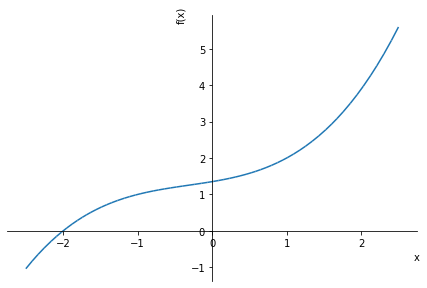

```python
f=sp.interpolate([(-2,0),(-1,1),(1,2),(2,3.89)],x)
sp.plot(f,(x,-2.5,2.5));
```

### 6. zadatak

Odredite sve nultočke polinoma $p(x)=-2x^7+3x^6+4x^5-5x^4+x^3+2x^2+8x+12.$

### Rješenje

```python
p=-2*x**7+3*x**6+4*x**5-5*x**4+x**3+2*x**2+8*x+12
p=p.as_poly()
```

#### sve nultočke u polju $\mathbb{C}$

```python
p.nroots()
```

$\displaystyle \left[ -1.26767180772764, \ -1.07474236732802, \ 2.13930159099512, \ -0.242131509213649 - 0.972540285478488 i, \ -0.242131509213649 + 0.972540285478488 i, \ 1.09368780124392 - 0.923733294950994 i, \ 1.09368780124392 + 0.923733294950994 i\right]$

#### samo realne nultočke

```python
samo_realne=list(filter(lambda x: sp.im(x)==0, p.nroots()))
samo_realne
```

$\displaystyle \left[ -1.26767180772764, \ -1.07474236732802, \ 2.13930159099512\right]$

najveća realna nultočka

```python
max(samo_realne)
```

$\displaystyle 2.13930159099512$

najmanja realna nultočka

```python
min(samo_realne)
```

$\displaystyle -1.26767180772764$

#### slika

```python
plt.rcParams['figure.figsize'] = 10,7
```

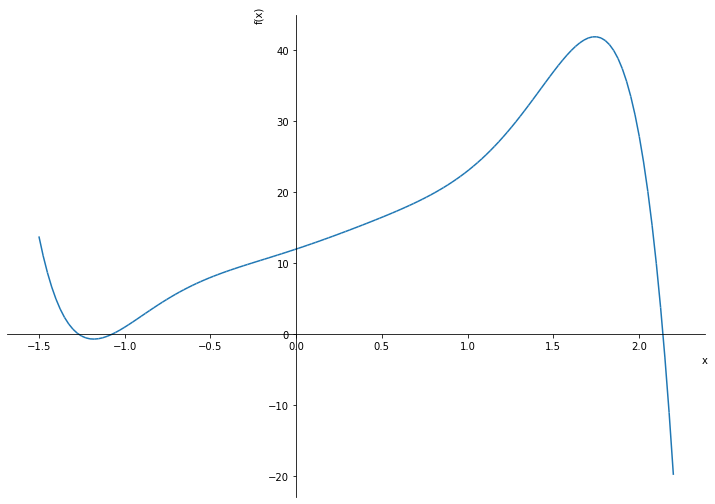

```python
sp.plot(p.as_expr(),(x,-1.5,2.2),adaptive=False,nb_of_points=150);
```

### 7. zadatak

Razvijte polinom $p(x)=-2x^7+3x^6+4x^5-5x^4+x^3+2x^2+8x+12$ po potencijama od $x+5.$

### Rješenje

```python
p=-2*x**7+3*x**6+4*x**5-5*x**4+x**3+2*x**2+8*x+12
razvoj=p.series(x,-5,8)
razvoj
```

$\displaystyle - 259937 x - 2 \left(x + 5\right)^{7} + 73 \left(x + 5\right)^{6} - 1136 \left(x + 5\right)^{5} + 9770 \left(x + 5\right)^{4} - 50149 \left(x + 5\right)^{3} + 153612 \left(x + 5\right)^{2} - 1112288$

U gornjem zapisu je nezgodno što nije posebno izdvojen član $x+5$. Možemo tome doskočiti jednostavnim trikom sa supstitucijom.

```python
u=sp.Symbol('u')
raz=razvoj.subs({x:u-5})
raz
```

$\displaystyle - 2 u^{7} + 73 u^{6} - 1136 u^{5} + 9770 u^{4} - 50149 u^{3} + 153612 u^{2} - 259937 u + 187397$

Član uz $(x+5)^1$

```python
raz.coeff(u,1)
```

$\displaystyle -259937$

Član uz $(x+5)^0$

```python
raz.coeff(u,0)
```

$\displaystyle 187397$

Član uz $(x+5)^4$

```python
raz.coeff(u,4)
```

$\displaystyle 9770$

### 8. zadatak

Odredite $a,b\in\mathbb{R}$ tako da $-2$ bude dvostruka nultočka polinoma $f(x)=x^4+2x^3+ax^2+(a+b)x+2.$

### Rješenje

```python
a,b=sp.symbols('a b')
f=x**4+2*x**3+a*x**2+(a+b)*x+2
f=f.as_poly()
```

```python
f1=f.diff(x)
f1.as_expr()
```

$\displaystyle 2 a x + a + b + 4 x^{3} + 6 x^{2}$

$f(-2)=0,\ f'(-2)=0$

```python
eq1=f(-2).as_expr()
eq2=f1(-2).as_expr()
eq1,eq2
```

$\displaystyle \left( 2 a - 2 b + 2, \ - 3 a + b - 8\right)$

$a=-\frac{7}{2},\ b=-\frac{5}{2}$

```python
sp.linsolve([eq1,eq2],[a,b])
```

$\displaystyle \left\{\left( - \frac{7}{2}, \ - \frac{5}{2}\right)\right\}$

#### Graf dobivenog polinoma

```python
f_rj=f.subs({a:sp.Rational(-7,2),b:sp.Rational(-5,2)})
f_rj.as_expr()
```

$\displaystyle x^{4} + 2 x^{3} - \frac{7 x^{2}}{2} - 6 x + 2$

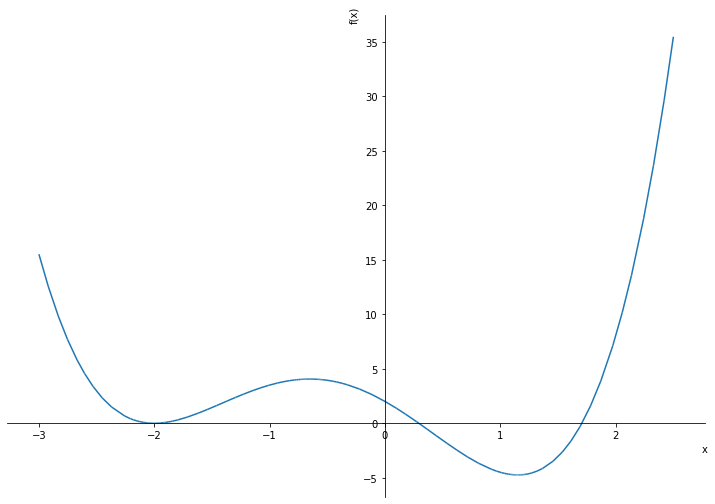

```python
sp.plot(f_rj.as_expr(),(x,-3,2.5));
```

nultočke

```python
f_rj.nroots()
```

$\displaystyle \left[ -2.0, \ -1.99999999999999, \ 0.292893218813452, \ 1.70710678118655\right]$